# Influenza burden in Mexico, as 2025

IMELDA

2025-08-24, last update August 24, 2025

# 01 Check working directory

(Important since many sub-folder paths depend on this)

```r
# Define inputs

year_analysis <- 2024
date_analysis <- "2024-12-03"

#year_analysis <- 2025
#date_analysis <- "2025-08-05"

file_name <- paste0("clean_respiratory_diseases_", date_analysis, ".Rdata")

# URLs
url_web <- "https://github.com/imelit/Bayesian_inference_class_2025/raw/main/data/"
url_disease <- paste0(url_web, file_name)
url_population <- paste0(url_web, "clean_mexican_population.RData")

# Load data
load(url(url_disease))
load(url(url_population))
```

# 02 Demographics of reported influenza cases

```r
# Keep only confirmed influenza cases
data_flu <- data_resp %>%
  filter(CLASIFICACION_FINAL_FLU == "CASO DE INFLUENZA CONFIRMADO")

# this data include all respiratory cases related to flu

# Keep only influenza positive cases
flu <- data_flu %>%
  filter(grepl("INFLUENZA", RESULTADO_PCR, ignore.case = TRUE))



summary(flu)
```

```
##  ID_REGISTRO                    ORIGEN                     SECTOR
##  Length:10040       USMER          :10040   SSA               :3847
##  Class :character   FUERA DE USMER :    0   IMSS              :2705
##  Mode  :character   NO ESPECIFICADO:    0   IMSS Bienestar OPD:2198
##                                             ISSSTE            : 957
##                                             ESTATAL           : 179
##                                             PEMEX             :  86
##                                             (Other)           :  68
##             ENTIDAD_UM                SEXO                ENTIDAD_RES
##  CIUDAD DE MÉXICO:2533   MUJER          :5828   CIUDAD DE MÉXICO:2089
##  QUERÉTARO       : 947   HOMBRE         :4212   QUERÉTARO       : 911
##  YUCATÁN         : 770   NO ESPECIFICADO:   0   YUCATÁN         : 764
##  PUEBLA          : 474                          MÉXICO          : 681
##  NUEVO LEÓN      : 443                          PUEBLA          : 483
##  JALISCO         : 382                          NUEVO LEÓN      : 448
##  (Other)         :4491                          (Other)         :4664
##          TIPO_PACIENTE  FECHA_INGRESO        FECHA_SINTOMAS
##  AMBULATORIO    :5834   Min.   :2024-01-01   Min.   :2024-01-01
##  HOSPITALIZADO  :4206   1st Qu.:2024-02-07   1st Qu.:2024-02-05
##  NO ESPECIFICADO:   0   Median :2024-03-20   Median :2024-03-18
##                         Mean   :2024-04-21   Mean   :2024-04-18
##                         3rd Qu.:2024-06-17   3rd Qu.:2024-06-15
##                         Max.   :2024-12-01   Max.   :2024-11-29
##
##    FECHA_DEF                     INTUBADO               NEUMONIA
##  Min.   :2024-01-05   SI             : 240   SI             :2329
##  1st Qu.:2024-02-08   NO             :3962   NO             :7711
##  Median :2024-03-29   NO APLICA      :5834   NO APLICA      :   0
##  Mean   :2024-04-21   SE IGNORA      :   0   SE IGNORA      :   0
##  3rd Qu.:2024-06-06   NO ESPECIFICADO:   4   NO ESPECIFICADO:   0
##  Max.   :2024-11-28
##  NA's   :9668
##       EDAD                 NACIONALIDAD             EMBARAZO
##  Min.   :  0.00   MEXICANA       :9976   SI             : 329
##  1st Qu.: 18.00   EXTRANJERA     :  64   NO             :5474
##  Median : 32.00   NO ESPECIFICADO:   0   NO APLICA      :4212
##  Mean   : 35.32                          SE IGNORA      :  25
##  3rd Qu.: 51.00                          NO ESPECIFICADO:   0
##  Max.   :108.00
##
```

[output cut: 65 more lines]

```
##  CASO DE INFLUENZA CONFIRMADO:10040      SI             :  23
##  INVÁLIDO POR LABORATORIO    :    0      NO             :  39
##  NO REALIZADO POR LABORATORIO:    0      NO APLICA      :   0
##  CASO SOSPECHOSO             :    0      SE IGNORA      :   0
##  NEGATIVO A INFLUENZA        :    0      NO ESPECIFICADO:9978
##
##
##               UCI       DEFUNCION        AGE_GROUP         YEAR
##  SI             : 135   NO :9668   0-4 years  : 769   Min.   :2024
##  NO             :4067   YES: 372   5-19 years :1843   1st Qu.:2024
##  NO APLICA      :5834              20-64 years:6148   Median :2024
##  SE IGNORA      :   0              65+ years  :1280   Mean   :2024
##  NO ESPECIFICADO:   4                                 3rd Qu.:2024
##                                                       Max.   :2024
##
```

Nota: Aunque se incluyen todas las clasificaciones por PCR, sólo las categorías con “INFLUENZA” corresponden a casos confirmados.

# 03 Demographics of reported influenza cases

## 03.1 Sectors attending cases

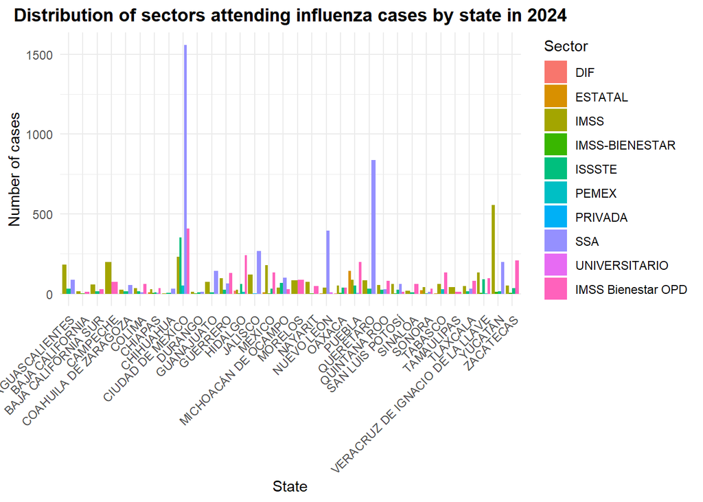

```r
cross_table_sectorEntidad <- data_flu %>%
  group_by(SECTOR, ENTIDAD_UM) %>%
  summarise(count = n(), .groups = "drop")

ggplot(cross_table_sectorEntidad, aes(x = ENTIDAD_UM, y = count, fill = SECTOR)) +
  geom_bar(stat = "identity", position = "dodge") +
  labs(
    title = paste("Distribution of sectors attending influenza cases by state in", year_analysis),
    x = "State",
    y = "Number of cases",
    fill = "Sector"
  ) +
  theme_minimal() +
  theme(
    axis.text.x = element_text(angle = 45, hjust = 1),
    plot.title = element_text(hjust = 0.5, face = "bold")
  )
```

Nota: La mayoría de los casos son atendidos en el sector público, aunque la distribución varía entre estados. Esto puede reflejar diferencias en acceso a servicios de salud.

# 04 Influenza types

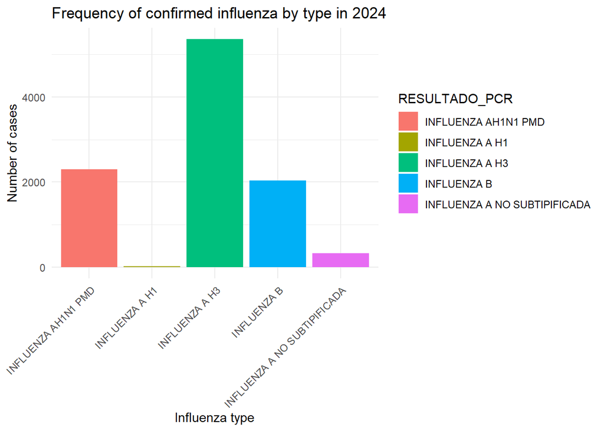

```r
ggplot(flu, aes(x = RESULTADO_PCR, fill = RESULTADO_PCR)) +
  geom_bar() +
  labs(
    title = paste("Frequency of confirmed influenza by type in", year_analysis),
    x = "Influenza type",
    y = "Number of cases"
  ) +
  theme_minimal() +
  theme(axis.text.x = element_text(angle = 45, hjust = 1))
```

Nota: Los subtipos más frecuentes permiten identificar qué cepas dominaron en la temporada. Esta información es clave para la planeación de la vacuna. Cuando se distribuyen las vacunas? ¿Para cuantos subtipo esta diseñanda una vacuna en Mexico?

## 04.1 Influenza cases stratified by age groups

```r
cases_by_age <- flu %>% count(AGE_GROUP, name = "Cases")

population_total <- population %>%
  filter(Year == year_analysis) %>%
  select(AGE_GROUP, POPULATION)

rate_age_grp <- cases_by_age %>%
  left_join(population_total) %>%
  mutate(rate_per_100k = round((Cases * 100000 / POPULATION), 2))
```

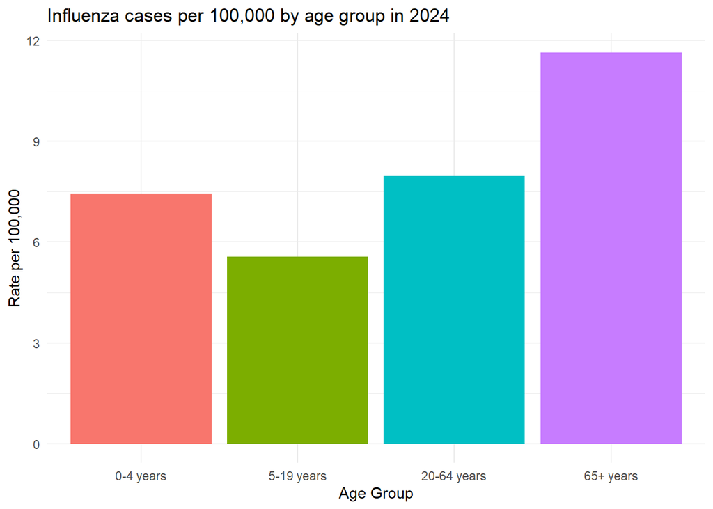

```r
ggplot(rate_age_grp, aes(x = AGE_GROUP, y = rate_per_100k, fill = AGE_GROUP)) +
  geom_col() +
  labs(
    title = paste("Influenza cases per 100,000 by age group in", year_analysis),
    y = "Rate per 100,000",
    x = "Age Group"
  ) +
  theme_minimal() +
  theme(legend.position = "none")
```

## 04.2 Daily influenza cases

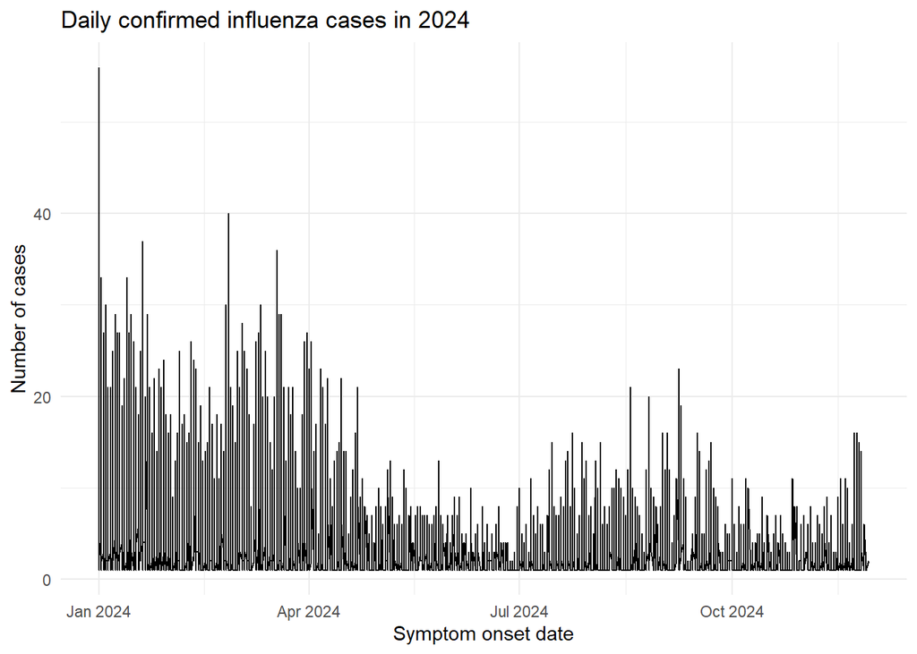

```r
daily_cases_by_type <- flu %>%
  group_by(FECHA_SINTOMAS, RESULTADO_PCR, AGE_GROUP) %>%
  summarise(CASOS = n(), .groups = "drop")

# Total daily confirmed cases
ggplot(daily_cases_by_type, aes(x = FECHA_SINTOMAS, y = CASOS)) +
  geom_line() +
  labs(
    title = paste("Daily confirmed influenza cases in", year_analysis),
    x = "Symptom onset date",
    y = "Number of cases"
  ) +
  theme_minimal()
```

Nota: El patrón temporal muestra la estacionalidad de influenza, con picos concentrados en invierno y principios de primavera.

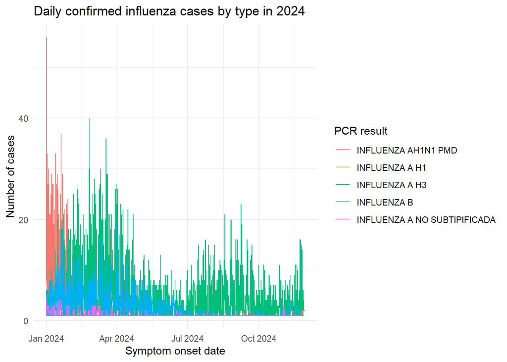

```r
# Daily cases by type
ggplot(daily_cases_by_type, aes(x = FECHA_SINTOMAS, y = CASOS, color = RESULTADO_PCR)) +
  geom_line() +
  labs(
    title = paste("Daily confirmed influenza cases by type in", year_analysis),
    x = "Symptom onset date",
    y = "Number of cases",
    color = "PCR result"
  ) +
  theme_minimal()
```

Nota: Algunos subtipos dominan en el pico epidémico, lo que sugiere su mayor transmisibilidad en cada sub-brote.

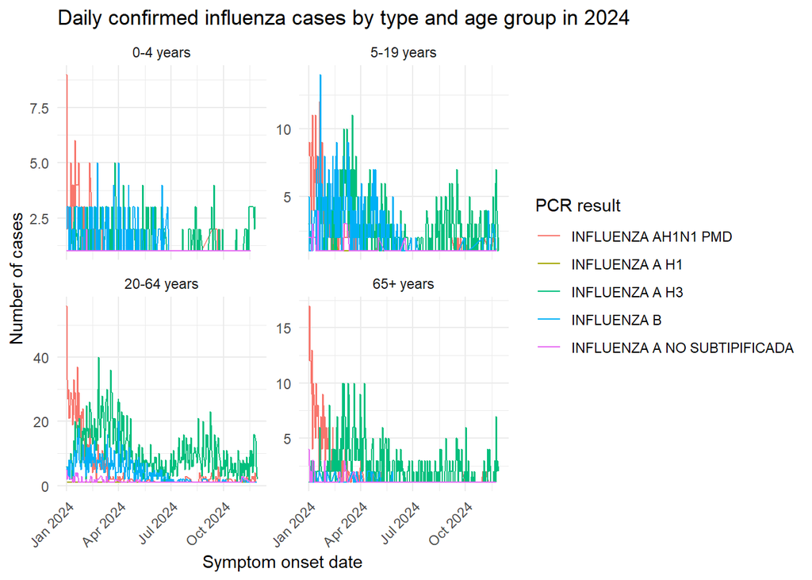

```r
# Faceted by age group
ggplot(daily_cases_by_type, aes(x = FECHA_SINTOMAS, y = CASOS, color = RESULTADO_PCR)) +
  geom_line() +
  facet_wrap(~AGE_GROUP, scales = "free_y") +
  labs(
    title = paste("Daily confirmed influenza cases by type and age group in", year_analysis),
    x = "Symptom onset date",
    y = "Number of cases",
    color = "PCR result"
  ) +
  theme_minimal() +
  theme(axis.text.x = element_text(angle = 45, hjust = 1))
```

Nota: es interesante ver el brote epidÉmico por influenza B para el grupo de edad 5-19 y 20-64 años, que no es tan evidente como los brotes por influenza AH1N1 y AH3.